# 4_4_triplet_loss_filtered_datasets

```python
from google.colab import drive

drive.mount('/proj')
```

```
Mounted at /proj
```

```python
!pip install -q -U umap-learn[plot] hdbscan tensorflow-addons #opencv-python==4.5.1.48
```

[output not shown]

```python
#Imports

import tensorflow as tf
import tensorflow_addons as tfa
import tensorflow_datasets as tfds

import io
import numpy as np

###UMAP seems to take a while to import due to a pynndescent dependency (which uses numba).
import umap
import umap.plot
import hdbscan
import os
import matplotlib.pyplot as plt
import numpy as np
import pandas as pd
import random
import seaborn as sns
import shutil
from glob import glob

from pathlib import Path
from sklearn.neighbors import KNeighborsClassifier, LocalOutlierFactor
```

In this attempt, I perform random filtering of the datasets. Recall that the class sizes are unbalanced, and that some images were of poor quality. My hope is that this filtering will reduce some of the noise in the dataset.

```python
CHECKPOINT_DIR="/proj/MyDrive/158780_Project_Dolphin_Computer_Vision/models/triplet_loss_dolphin/training/"
SEED = 100
VAL_PROP = 0.15
DIM=224
CHANNELS=3
train_dir = "/content/train"
test_dir = "/content/test"
```

```python
shutil.rmtree(data_dir, ignore_errors=True)
```

```python
!unzip /proj/MyDrive/158780_Project_Dolphin_Computer_Vision/images/filtered_final_pigmentation_catalogue_2016.zip -d /content
!unzip /proj/MyDrive/158780_Project_Dolphin_Computer_Vision/images/filtered_final_pigmentation_catalogue_2016_test.zip -d /content
```

[output not shown]

[output cut: 4067 more lines]

[output not shown]

```python
!mv /content/content/final_pigmentation_catalogue_2016 /content/train
!mv /content/content/test /content/test
```

```
mv: cannot stat '/content/content/test': No such file or directory
```

I have some solid results with this filtered images. So this code has been filtered out.

```python
# df_rows = []
# pigmentation_classes = glob(f'{data_dir}/*')
# for pigmentation_class in pigmentation_classes:
#     for image_file in glob(pigmentation_class + '/*.png'):
#         df_row = {"identity": Path(pigmentation_class).name, "image": Path(image_file).name, "path": image_file, "parent": Path(image_file).parent }
#         df_rows.append(df_row)

# pigmentation_df = pd.DataFrame(df_rows)
# pigmentation_counts = pigmentation_df.groupby('identity').size().reset_index(name='counts').sort_values('counts', ascending=False)
# filtered_identities = pigmentation_counts[pigmentation_counts['counts'] > 30]["identity"]
```

```python
# TRAIN_DIR = "/content/train"
# shutil.rmtree(TRAIN_DIR, ignore_errors=True)
# Path(TRAIN_DIR).mkdir(parents=True, exist_ok=True)

# for id in filtered_identities:
#   Path(TRAIN_DIR + "/" + id).mkdir(parents=True, exist_ok=True)
```

```python
# filtered_pigmentation_df = pigmentation_df[pigmentation_df.identity.isin(filtered_identities)]
# filtered_pigmentation_df[["path", "image", "identity"]].apply(
#     lambda x: shutil.copy2(x.path, f"{TRAIN_DIR}/{x.identity}/{x.image}"), axis = 1
)
```

[output not shown]

```python
# shutil.rmtree(test_dir, ignore_errors=True)
# for dir in Path(TRAIN_DIR).glob('*'):
#   class_test_dir = f"/content/test/{dir.name}"
#   Path(class_test_dir).mkdir(parents = True, exist_ok = True)
#   images = list(dir.glob('*.png'))
#   test_prop = round(len(images) * 0.1)
#   for i in range(test_prop):
#     test_file = random.choice(images)
#     while os.path.exists(f"{class_test_dir}/{test_file.name}"): test_file = random.choice(images)
#     shutil.move(str(test_file), class_test_dir)
```

```python
!ls /content/train/0004
```

```
HG_120524_135_E1_HT.png       HG_131115_2224_E4_CL_AII.png
HG_130719_107_E2_CL.png       HG_131115_2225_E4_CL_AII.png
HG_130719_108_E2_CL.png       HG_131115_322_E1_BL.png
HG_130719_109_E2_CL.png       HG_131115_336_E1_BL.png
HG_130719_112_E2_CL.png       HG_131115_363_E1_BL.png
HG_130719_113_E2_CL.png       HG_131115_419_E1_BL.png
HG_130719_114_E2_CL_N4.png    HG_131115_420_E1_BL.png
HG_130719_268_E2_CL.png       HG_131115_421_E1_BL.png
HG_130719_269_E2_CL.png       HG_131115_425_E1_BL.png
HG_130719_274_E2_CL.png       HG_131115_504_E4_KR_AII_N93.png
HG_130719_275_E2_CL.png       HG_131115_617_E4_KR_AII.png
HG_130719_279_E2_CL.png       HG_131115_618_E4_KR_AII.png
HG_130719_280_E2_CL.png       HG_131117_1047_E5_CL_AII.png
HG_130719_281_E2_CL.png       HG_131117_1048_E5_CL_AII.png
HG_130820_322_E2_MQ.png       HG_131117_1049_E5_CL_AII.png
HG_130820_325_E2_MQ.png       HG_131117_1071_E5_CL_AII.png
HG_130820_339_E2_MQ.png       HG_131117_1073_E5_CL_AII.png
HG_131115_2179_E4_CL_AII.png  HG_131117_1074_E5_CL_AII.png
HG_131115_2180_E4_CL_AII.png  HG_131117_1146_E5_CL_AII.png
HG_131115_2181_E4_CL_AII.png  HG_131117_1147_E5_CL_AII.png
HG_131115_2190_E4_CL_AII.png  HG_131117_1148_E5_CL_AII.png
HG_131115_2191_E4_CL_AII.png  HG_131117_265_E5_KR_AII.png
HG_131115_2200_E4_CL_AII.png  HG_131117_292_E5_KR_AII_N59.png
HG_131115_2223_E4_CL_AII.png  HG_131117_993_E5_CL_AII.png
```

```python
!ls /content/test/0004
```

```
HG_120524_153_E1_LH_N3.png    HG_131115_539_E4_KR_AII.png
HG_130820_340_E2_MQ_N36.png   HG_131117_1072_E5_CL_AII.png
HG_131115_2201_E4_CL_AII.png
```

```python
from tensorflow.keras.applications.resnet import ResNet50
base_model = ResNet50(include_top=False, pooling='avg', weights='imagenet', input_shape=(DIM,DIM,CHANNELS))
base_model.trainable = True

model = tf.keras.Sequential([
    tf.keras.layers.Conv2D(filters=64, kernel_size=2, padding='same', activation='relu', input_shape=(DIM,DIM,CHANNELS)),
    tf.keras.layers.MaxPooling2D(pool_size=2),
    tf.keras.layers.Dropout(0.5),
    tf.keras.layers.Conv2D(filters=32, kernel_size=2, padding='same', activation='relu'),
    tf.keras.layers.MaxPooling2D(pool_size=2),
    tf.keras.layers.Dropout(0.5),
    tf.keras.layers.Flatten(),
    tf.keras.layers.Dense(256, activation=None), # No activation on final dense layer
    tf.keras.layers.Lambda(lambda x: tf.math.l2_normalize(x, axis=1)) # L2 normalize embeddings

])

# model = tf.keras.Sequential([
#     tf.keras.layers.experimental.preprocessing.RandomFlip("horizontal", input_shape=(DIM,DIM,CHANNELS)),
#     tf.keras.layers.experimental.preprocessing.RandomRotation(0.2),
#     tf.keras.layers.experimental.preprocessing.RandomZoom(0.1),
#     tf.keras.layers.experimental.preprocessing.RandomTranslation((-.15, .15), (-.15, .15), fill_mode='reflect',interpolation='bilinear'),
#     tf.keras.layers.experimental.preprocessing.Rescaling(1./255, input_shape=(DIM,DIM,CHANNELS)),
#     base_model,
#     tf.keras.layers.Dense(1024, activation=tf.keras.layers.LeakyReLU(alpha=0.3)),
#     tf.keras.layers.Dropout(0.5),
#     tf.keras.layers.Dense(128, activation=None),
#     tf.keras.layers.Lambda(lambda x: tf.math.l2_normalize(x, axis=1))
# ])

# model = tf.keras.Sequential([
#     tf.keras.layers.experimental.preprocessing.RandomFlip("horizontal", input_shape=(DIM,DIM,CHANNELS)),
#     tf.keras.layers.experimental.preprocessing.RandomRotation(0.15),
#     tf.keras.layers.experimental.preprocessing.RandomZoom(0.1),
#     tf.keras.layers.experimental.preprocessing.RandomTranslation((-.15, .15), (-.15, .15), fill_mode='reflect',interpolation='bilinear'),
#     tf.keras.layers.experimental.preprocessing.Rescaling(1./255, input_shape=(DIM,DIM,CHANNELS)),
#     tf.keras.layers.Conv2D(filters=64, kernel_size=2, padding='same', activation='relu', input_shape=(DIM,DIM,CHANNELS)),
#     tf.keras.layers.MaxPooling2D(pool_size=2),
#     tf.keras.layers.BatchNormalization(),
#     tf.keras.layers.Conv2D(filters=32, kernel_size=2, padding='same', activation='relu'),
#     tf.keras.layers.MaxPooling2D(pool_size=2),
#     tf.keras.layers.BatchNormalization(),
#     tf.keras.layers.Flatten(),
#     tf.keras.layers.Dense(128, activation=None), # No activation on final dense layer
#     tf.keras.layers.Lambda(lambda x: tf.math.l2_normalize(x, axis=1)) # L2 normalize embeddings
# ])
```

```python
model.build(input_shape=(DIM,DIM,CHANNELS))
model.summary()
```

```
Model: "sequential_1"
_________________________________________________________________
Layer (type)                 Output Shape              Param #
=================================================================
conv2d_2 (Conv2D)            (None, 224, 224, 64)      832
_________________________________________________________________
max_pooling2d_2 (MaxPooling2 (None, 112, 112, 64)      0
_________________________________________________________________
dropout_2 (Dropout)          (None, 112, 112, 64)      0
_________________________________________________________________
conv2d_3 (Conv2D)            (None, 112, 112, 32)      8224
_________________________________________________________________
max_pooling2d_3 (MaxPooling2 (None, 56, 56, 32)        0
_________________________________________________________________
dropout_3 (Dropout)          (None, 56, 56, 32)        0
_________________________________________________________________
flatten_1 (Flatten)          (None, 100352)            0
_________________________________________________________________
dense_1 (Dense)              (None, 256)               25690368
_________________________________________________________________
lambda_1 (Lambda)            (None, 256)               0
=================================================================
Total params: 25,699,424
Trainable params: 25,699,424
Non-trainable params: 0
_________________________________________________________________
```

We load the dataset, visualise the classes, and apply both pre-fetching and caching for performance.

```python
batch_size=128

def build_data(data_dir, batch_size):
  train_dataset = tf.keras.preprocessing.image_dataset_from_directory(
      data_dir,
      labels="inferred",
      label_mode="int",
      class_names=None,
      color_mode="rgb",
      batch_size=batch_size,
      image_size=(DIM, DIM),
      shuffle=True,
      seed=SEED,
      validation_split=VAL_PROP,
      subset="training",
      interpolation="bilinear",
      follow_links=False,
  )

  val_dataset = tf.keras.preprocessing.image_dataset_from_directory(
      data_dir,
      labels="inferred",
      label_mode="int",
      class_names=None,
      color_mode="rgb",
      batch_size=batch_size,
      image_size=(DIM, DIM),
      shuffle=True,
      seed=SEED,
      validation_split=VAL_PROP,
      subset="validation",
      follow_links=False,
  )

  test_dataset = tf.keras.preprocessing.image_dataset_from_directory(
      test_dir,
      labels="inferred",
      label_mode="int",
      color_mode="rgb",
      # batch_size=batch_size,
      image_size=(DIM, DIM),
      shuffle=True,
      seed=SEED,
  )
  return train_dataset, val_dataset, test_dataset

def prefetch_data(data_dir, batch_size):
  train_dataset, val_dataset, test_dataset = build_data(data_dir, batch_size)
  train_dataset = train_dataset.cache().prefetch(buffer_size=tf.data.AUTOTUNE)
  val_dataset = val_dataset.cache().prefetch(buffer_size=tf.data.AUTOTUNE)
  test_dataset = test_dataset.cache().prefetch(buffer_size=tf.data.AUTOTUNE)
  return train_dataset, val_dataset, test_dataset

train_dataset, val_dataset, test_dataset = build_data(train_dir, batch_size)
```

```
Found 3364 files belonging to 186 classes.
Using 2860 files for training.
Found 3364 files belonging to 186 classes.
Using 504 files for validation.
Found 382 files belonging to 186 classes.
```

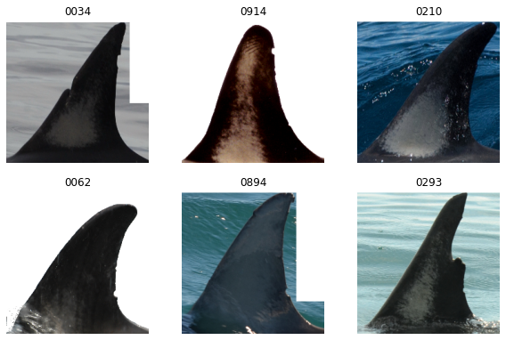

```python
import matplotlib.pyplot as plt

class_names = train_dataset.class_names
plt.figure(figsize=(10, 10))
for images, labels in train_dataset.take(1):
  for i in range(6):
    ax = plt.subplot(3, 3, i + 1)
    plt.imshow(images[i].numpy().astype("uint8"))
    plt.title(class_names[labels[i]])
    plt.axis("off")
```

We can see a diverse mixture of images and classes. Some still contain their background (the sea), while others have been covered with an alpha layer.

```python
train_dataset, val_dataset, test_dataset = prefetch_data(train_dir, batch_size)
```

```
Found 3364 files belonging to 186 classes.
Using 2860 files for training.
Found 3364 files belonging to 186 classes.
Using 504 files for validation.
Found 382 files belonging to 186 classes.
```

We first perform online learning with triplet hard loss and a soft margin of 1. The Adamax compiler is used, as it can apparently improve performance for networks that deal with embeddings.

```python
def scheduler(epoch, lr):
  if epoch < 10:
    return lr
  else:
    return lr * tf.math.exp(-0.1)
```

```python
model.compile(
  optimizer=tf.keras.optimizers.Adamax(),
  loss=tfa.losses.TripletHardLoss(1, soft = True),
)
```

```python
history = model.fit(
  train_dataset,
  validation_data = val_dataset,
  epochs = 50,
  callbacks = [
    tf.keras.callbacks.LearningRateScheduler(scheduler),
    tf.keras.callbacks.EarlyStopping(monitor='val_loss', mode='min', restore_best_weights = True, patience = 10),
    tf.keras.callbacks.ModelCheckpoint(f"{CHECKPOINT_DIR}/training_filtered_resnet_aug", monitor= 'val_loss', save_best_only = True, mode = "min", save_weights_only = True),
    tf.keras.callbacks.ReduceLROnPlateau(monitor="val_loss", factor=0.33, patience=2, mode="min", min_delta=0.0001, min_lr = 0)
  ]
)
```

We visualise the training results.

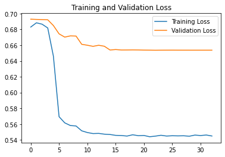

```python
def plot_loss(history):
  epochs = len(history.history['loss'])
  loss = history.history['loss']
  val_loss = history.history['val_loss']
  epochs_range = range(epochs)
  plt.plot(epochs_range, loss, label='Training Loss')
  plt.plot(epochs_range, val_loss, label='Validation Loss')
  plt.legend(loc='upper right')
  plt.title('Training and Validation Loss')
  plt.show()

plot_loss(history)
```

We have quickly reached a validation loss plateau.

So, we will generate the embeddings, visualise them, and use a KNN classifier.

```python
train_embeddings = model.predict(train_dataset)
test_embeddings = model.predict(test_dataset)
train_embeddings.shape
```

```
(2860, 256)
```

We retrieve the class labels.

```python
y_train = np.concatenate([y for x, y in train_dataset], axis=0)
y_test = np.concatenate([y for x, y in test_dataset], axis=0)
y_train[0:100]
```

```
array([ 40,  92,  99,  56,   3,  88, 140,  53,  55, 130, 153, 133,  87,
       142,  62,  98,  28, 149, 155,  63, 139,  57, 138,   7,  18,  60,
         3, 182, 154,  43,  55, 133,  59, 120, 154,  42, 112,  30,  49,
        55, 131,   1,   8, 113, 172,  56,  38,  43,   1,  27,  13,  13,
        70, 128, 114, 115,   9,  95,  93,  21,  60, 180,  58,  95, 121,
        79,  83,  43, 128,  75,  43,   4,  54,  44,   8,  13,  18, 120,
        60,  55, 154, 144, 168, 119, 167,   8,  62,  81, 114, 153,  62,
       157,  21, 174,   1,  45,  64, 169,  22,  59], dtype=int32)
```

Next, we visualise the results using UMAP.

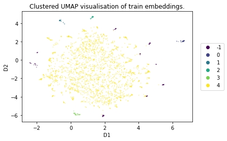

```python
mapper=umap.UMAP( n_neighbors = 100, min_dist= 0.1).fit(train_embeddings, y_train)
cluster = hdbscan.HDBSCAN(
    algorithm ='best',
    approx_min_span_tree = True,
    gen_min_span_tree = False,
    leaf_size = 40,
    metric='euclidean',
    min_cluster_size = 25,
    min_samples = 25,
    p = None
).fit(mapper.embedding_)

plt.title("Clustered UMAP visualisation of train embeddings.")
scatter = plt.scatter(
    mapper.embedding_[:, 0],
    mapper.embedding_[:, 1],
    c = cluster.labels_,
    s = 0.1,
)

plt.legend(
  handles = scatter.legend_elements()[0],
  labels = pd.Series(cluster.labels_.tolist()).astype("string").sort_values().unique(),
  loc="right",
  bbox_to_anchor=(1.2, 0.5)
)
plt.xlabel("D1")
plt.ylabel("D2")
plt.show();
```

We can see that most of the data forms a Gaussian sphere, but that there is some divergence from the central spheroid. These divergences could be distinct individuals.

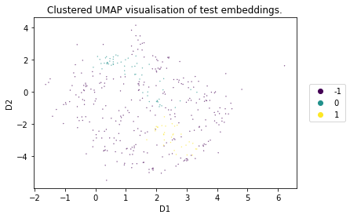

```python
mapper_embeddings = mapper.transform(test_embeddings)
cluster = hdbscan.HDBSCAN(
    algorithm ='best',
    approx_min_span_tree = True,
    gen_min_span_tree = False,
    leaf_size = 40,
    metric='euclidean',
    min_cluster_size = 25,
    min_samples = 25,
    p = None
).fit(mapper_embeddings)

plt.title("Clustered UMAP visualisation of test embeddings.")
scatter = plt.scatter(
    mapper_embeddings[:, 0],
    mapper_embeddings[:, 1],
    c = cluster.labels_,
    s = 0.1,
)

plt.legend(
  handles = scatter.legend_elements()[0],
  labels = pd.Series(cluster.labels_.tolist()).astype("string").sort_values().unique(),
  loc="right",
  bbox_to_anchor=(1.2, 0.5)
)
plt.xlabel("D1")
plt.ylabel("D2")
plt.show();
```

Unfortunately, these results are not promising. The clusters are not well-formed.

We next fit a KNN classifier to the 2D UMAP embeddings.

```python
knn=KNeighborsClassifier(100)
knn.fit(mapper.embedding_, y_train)
knn.score(mapper_embeddings, y_test)
```

```
0.09162303664921466
```

The KNN classifier has an accuracy of roughly 9%. Not promising, at all!

We fit a KNN classifier to the triplet loss embeddings.

```python
knn=KNeighborsClassifier(100)
knn.fit(train_embeddings, y_train)
knn.score(test_embeddings, y_test)
```

```
0.19895287958115182
```

Better. The accuracy score has doubled to nearly 20%. But there's still work to do.

We next repeat this process with Local Outlier Factor.

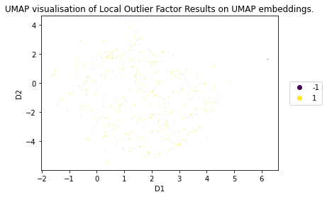

```python
lof=LocalOutlierFactor(100, novelty = True)
lof.fit(mapper.embedding_, y_train)
lof_labels = lof.predict(mapper_embeddings)

plt.title("UMAP visualisation of Local Outlier Factor Results on UMAP embeddings.")
scatter = plt.scatter(
    mapper_embeddings[:, 0],
    mapper_embeddings[:, 1],
    c = lof_labels,
    s = 0.1,
)

plt.legend(
  handles = scatter.legend_elements()[0],
  labels = pd.Series(lof_labels.tolist()).astype("string").sort_values().unique(),
  loc="right",
  bbox_to_anchor=(1.2, 0.5)
)
plt.xlabel("D1")
plt.ylabel("D2")
plt.show();
```

From above, we see that LOF has failed to identify outliers with the UMAP embeddings. The degree of seperation within the data isn't great enough.

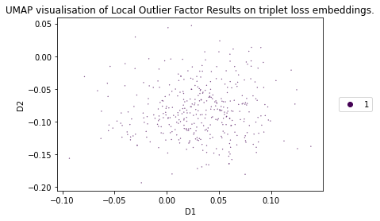

```python
lof=LocalOutlierFactor(100, novelty = True)
lof.fit(train_embeddings, y_train)
lof_labels = lof.predict(test_embeddings)

plt.title("UMAP visualisation of Local Outlier Factor Results on triplet loss embeddings.")
scatter = plt.scatter(
    test_embeddings[:, 0],
    test_embeddings[:, 1],
    c = lof_labels,
    s = 0.1,
)

plt.legend(
  handles = scatter.legend_elements()[0],
  labels = pd.Series(lof_labels.tolist()).astype("string").sort_values().unique(),
  loc="right",
  bbox_to_anchor=(1.2, 0.5)
)
plt.xlabel("D1")
plt.ylabel("D2")
plt.show();
```

Likewise, we see that LOF has failed to identify outliers with the triplet loss embeddings.

```python
%%shell
jupyter nbconvert --to html /content/4_4_triplet_loss_filtered_datasets.ipynb
```

[output not shown]